# Betke-Briana-ADA-homework-3

#### Superimpose line on ggplot and add model equation to the plot

First, I wanted to take out the coefficients of the models to embed into the equation for the graph. So I save the tidy model output as a data frame then put them into the paste function to test how it would look. This took a while because I am bad with paste functions…..apparently.

```r
values <- as.data.frame(tidy(mod)) # the data frame

# testing the paste
paste("longevity = ", paste(round(values$estimate[1],2), paste(round(values$estimate[2],2), "brain size", sep = "*"), sep=" + "), sep="")
```

```
## [1] "longevity = 248.95 + 1.22*brain size"
```

transformed version

```r
log_values <- as.data.frame(tidy(log_mod))

paste("longevity = ", paste(round(log_values$estimate[1],2), paste(round(log_values$estimate[2],2), "brain size", sep = "*"), sep=" + "), sep="")
```

```
## [1] "longevity = 4.88 + 0.23*brain size"
```

Now on to ggplot! Adding the equation to the graph using the geom_text().

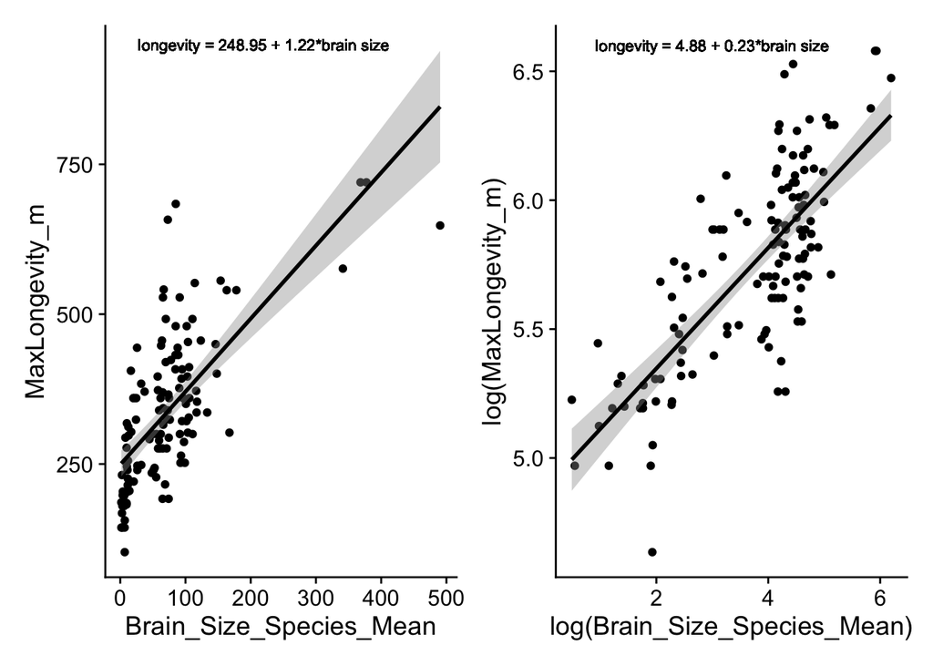

```r
mod_plot <- ggplot(d, aes(y = MaxLongevity_m, x = Brain_Size_Species_Mean)) +
        geom_point()+
        geom_smooth(method = "lm", color = "black", formula = y ~ x) +
        geom_text(x = 220, y = 950, size = 3, label = paste("longevity = ",
                                                  paste(round(values$estimate[1],2),
                                                        paste(round(values$estimate[2],2),
                                                              "brain size", sep = "*"), sep=" + "), sep=""))

log_mod_plot <- ggplot(d, aes(y = log(MaxLongevity_m), x = log(Brain_Size_Species_Mean))) +
        geom_point()+
        geom_smooth(method = "lm", color = "black", formula = y ~ x) +
        geom_text(x = 3.0, y = 6.60, size = 3, label = paste("longevity = ",
                                                  paste(round(log_values$estimate[1],2),
                                                        paste(round(log_values$estimate[2],2),
                                                              "brain size", sep = "*"), sep=" + "), sep=""))
# multiplot time
library(patchwork)
mod_plot + log_mod_plot
```

#### Hypothesis test

H0: There is no linear relationship (β1=0)  
HA: There is a linear relationship (β1≠0)

The p-values for the explanatory variable in both models are less than 0.05.Indicating that there is significant evidence of a linear relationship.

```r
values
```

```
##                      term  estimate  std.error statistic      p.value
## 1             (Intercept) 248.95227 11.1111143   22.4057 8.910319e-46
## 2 Brain_Size_Species_Mean   1.21799  0.1100879   11.0638 2.685909e-20
```

```r
log_values
```

```
##                          term  estimate  std.error statistic       p.value
## 1                 (Intercept) 4.8789509 0.06907361  70.63408 3.321721e-103
## 2 log_Brain_Size_Species_Mean 0.2341496 0.01780887  13.14792  2.165214e-25
```

90% CI for slope estimate untransformed:

```r
alpha <- 0.10
(CI <- tidy(mod, conf.int = TRUE, conf.level = 1 - alpha))
```

```
## # A tibble: 2 x 7
##   term                  estimate std.error statistic  p.value conf.low conf.high
##   <chr>                    <dbl>     <dbl>     <dbl>    <dbl>    <dbl>     <dbl>
## 1 (Intercept)             249.      11.1        22.4 8.91e-46   231.      267.
## 2 Brain_Size_Species_M…     1.22     0.110      11.1 2.69e-20     1.04      1.40
```

90% CI for slope estimate transformed:

```r
(CI <- tidy(log_mod, conf.int = TRUE, conf.level = 1 - alpha))
```

```
## # A tibble: 2 x 7
##   term                 estimate std.error statistic   p.value conf.low conf.high
##   <chr>                   <dbl>     <dbl>     <dbl>     <dbl>    <dbl>     <dbl>
## 1 (Intercept)             4.88     0.0691      70.6 3.32e-103    4.76      4.99
## 2 log_Brain_Size_Spec…    0.234    0.0178      13.1 2.17e- 25    0.205     0.264
```

#### Adding 90% CI and Prediction interval to scatter plot

First with the untransformed variables:

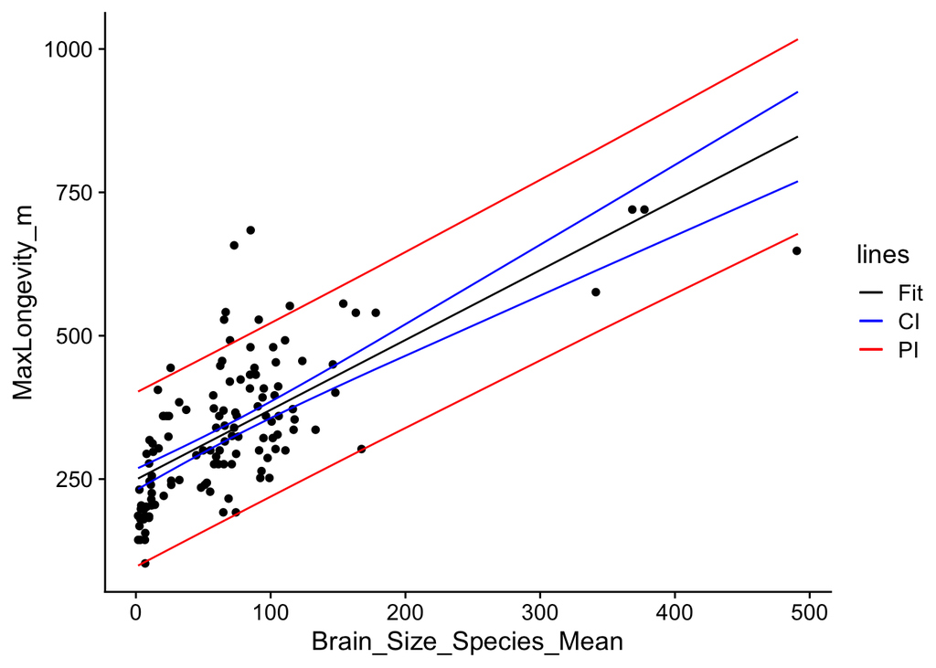

```r
ci <- predict(mod,
  newdata = data.frame(Brain_Size_Species_Mean = d$Brain_Size_Species_Mean),
  interval = "confidence", level = 1 - alpha
)
ci <- data.frame(ci)
ci <- cbind(d$Brain_Size_Species_Mean,ci)
names(ci) <- c("Brain_Size_Species_Mean", "c.fit", "c.lwr", "c.upr")

# prediction interval
pi <- predict(mod,
  newdata = data.frame(Brain_Size_Species_Mean = d$Brain_Size_Species_Mean),
  interval = "prediction", level = 0.90
)

pi <- data.frame(pi)
pi <- cbind(d$Brain_Size_Species_Mean,pi)
names(pi) <- c("Brain_Size_Species_Mean", "p.fit", "p.lwr", "p.upr")

mod_plot2 <- ggplot(data = d, aes(x = Brain_Size_Species_Mean, y = MaxLongevity_m)) +
  geom_point() +
  geom_line(data = ci, aes(x = Brain_Size_Species_Mean, y = c.fit, color = "Fit")) +
  geom_line(data = ci, aes(x = Brain_Size_Species_Mean, y = c.lwr, color = "CI")) +
  geom_line(data = ci, aes(x = Brain_Size_Species_Mean, y = c.upr, color = "CI")) +
  geom_line(data = pi, aes(x = Brain_Size_Species_Mean, y = p.lwr, color = "PI")) +
  geom_line(data = pi, aes(x = Brain_Size_Species_Mean, y = p.upr, color = "PI"))

(mod_plot_2 <- mod_plot2 + scale_color_manual(name = "lines",
                        breaks = c("Fit", "CI", "PI"),
                        values = c("Fit" = "black", "CI" = "blue", "PI" = "red")))
```

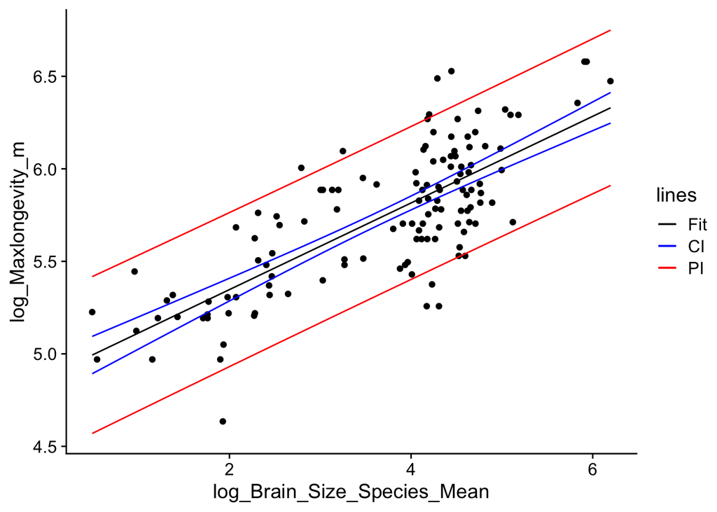

```r
log_ci <- predict(log_mod,
  newdata = data.frame(log_Brain_Size_Species_Mean = d$log_Brain_Size_Species_Mean),
  interval = "confidence", level = 1 - alpha
)
log_ci <- data.frame(log_ci)
log_ci <- cbind(log(d$Brain_Size_Species_Mean),log_ci)
names(log_ci) <- c("Brain_Size_Species_Mean", "c.fit", "c.lwr", "c.upr")

# prediction interval
log_pi <- predict(log_mod,
  newdata = data.frame(log_Brain_Size_Species_Mean = d$log_Brain_Size_Species_Mean),
  interval = "prediction", level = 0.90
)

log_pi <- data.frame(log_pi)
log_pi <- cbind(log(d$Brain_Size_Species_Mean),log_pi)
names(log_pi) <- c("Brain_Size_Species_Mean", "p.fit", "p.lwr", "p.upr")

log_mod_plot2 <- ggplot(data = d, aes(x = log_Brain_Size_Species_Mean, y = log_Maxlongevity_m)) +
  geom_point() +
  geom_line(data = log_ci, aes(x = Brain_Size_Species_Mean, y = c.fit, color = "Fit")) +
  geom_line(data = log_ci, aes(x = Brain_Size_Species_Mean, y = c.lwr, color = "CI")) +
  geom_line(data = log_ci, aes(x = Brain_Size_Species_Mean, y = c.upr, color = "CI")) +
  geom_line(data = log_pi, aes(x = Brain_Size_Species_Mean, y = p.lwr, color = "PI")) +
  geom_line(data = log_pi, aes(x = Brain_Size_Species_Mean, y = p.upr, color = "PI"))
(log_mod_pot2 <- log_mod_plot2 + scale_color_manual(name = "lines",
                        breaks = c("Fit", "CI", "PI"),
                        values = c("Fit" = "black", "CI" = "blue", "PI" = "red")))
```

#### Point estimate

Untransformed model

```r
pi_single <- predict(mod,
  newdata = data.frame(Brain_Size_Species_Mean = 750),
  interval = "prediction", level = 0.90
)
pi_single
```

```
##        fit      lwr      upr
## 1 1162.445 966.8151 1358.075
```

Transformed model:

```r
log_pi_single <- predict(log_mod,
  newdata = data.frame(log_Brain_Size_Species_Mean = log(750)),
  interval = "prediction", level = 0.90
)
log_pi_single
```

```
##        fit      lwr      upr
## 1 6.429038 6.006708 6.851368
```

I would not trust the models to predict the logevity of this value accurately. Looking at the maximum value of brain size for the variable, 750 gm is not a value contained in the dataset. The highest value in the dataset is 491.27 gm. Using this value in the model would be considered extrapolation as this is applying a value outside of the range of the observed data in which the model was generated.

#### Looking @ the models, which is better and why?

First, lets look at the residuals. For the untransformed data

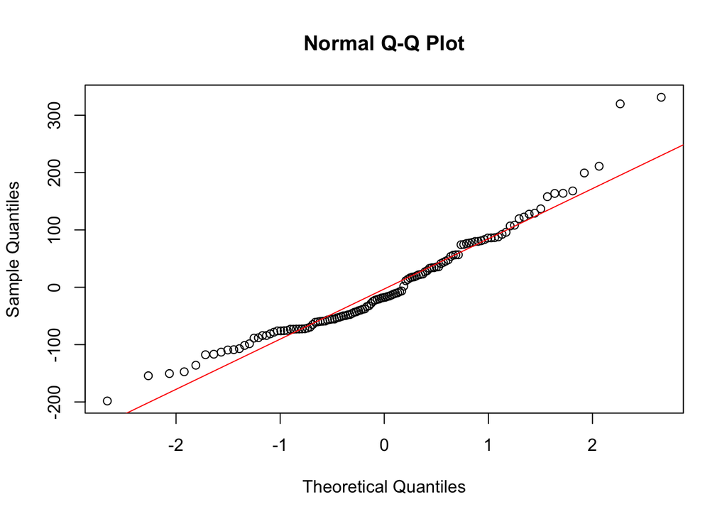

```r
qqnorm(mod$residuals)
qqline(mod$residuals, col = "red")
```

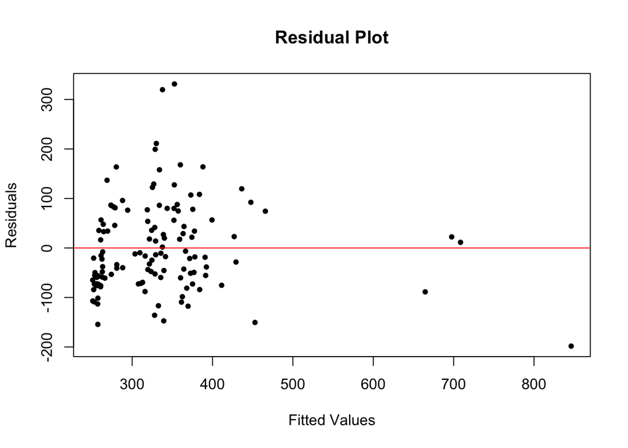

```r
plot(mod$fitted.values, mod$residuals, xlab = "Fitted Values",
    ylab = "Residuals", main = "Residual Plot", pch = 20)
abline(h = 0, col = "red")
```

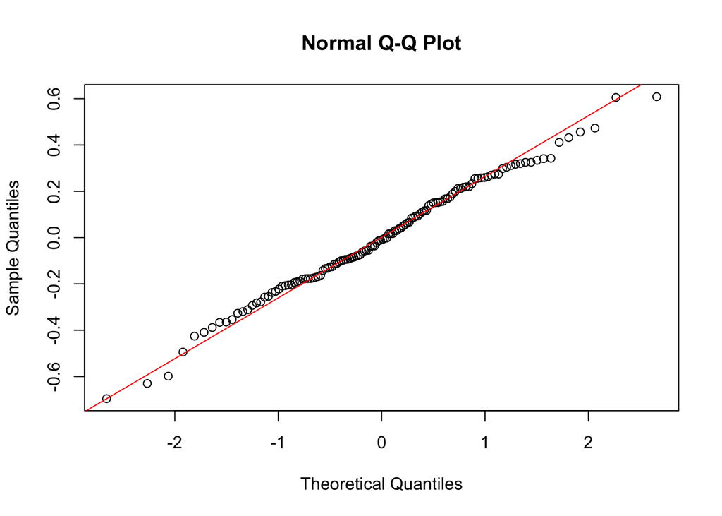

```r
qqnorm(log_mod$residuals)
qqline(log_mod$residuals, col = "red")
```

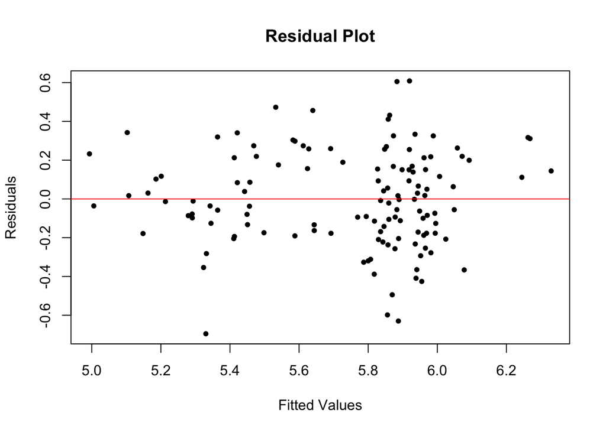

```r
plot(log_mod$fitted.values, log_mod$residuals, xlab = "Fitted Values",
    ylab = "Residuals", main = "Residual Plot", pch = 20)
abline(h = 0, col = "red")
```

I would say that the model with the log transformed variables is better. The transformations seem to improve normality and equal varience of the residuals.

### Challenge 2:

Run the lm:

```r
tidy(lm(log(HomeRange_km2)~log(Body_mass_female_mean), data = d))
```

```
## # A tibble: 2 x 5
##   term                       estimate std.error statistic  p.value
##   <chr>                         <dbl>     <dbl>     <dbl>    <dbl>
## 1 (Intercept)                   -9.44    0.673      -14.0 3.82e-28
## 2 log(Body_mass_female_mean)     1.04    0.0849      12.2 1.45e-23
```

On to the boostrapping. I get now that I didn’t have to go the list route…but I did…

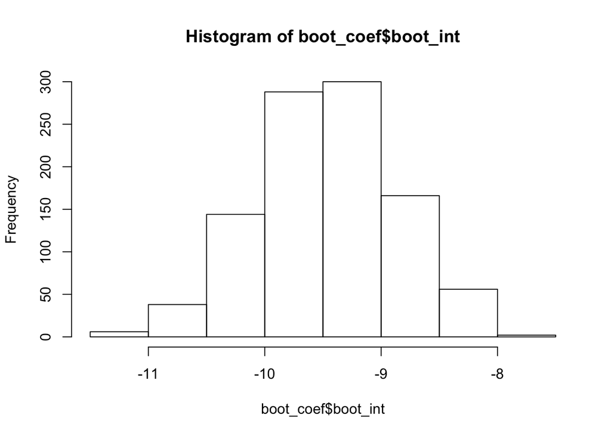

```r
# selecting columns for analysis for simplicity. Removing NAs because it seemed to solve my loop problems...?
r <- d %>%
  select(HomeRange_km2, Body_mass_female_mean) %>%
  drop_na()

# Now set up the loop
k <- 1000
n <- dim(r)[1]

s <- list(length = k)
coef <- list(length = k)

for (i in 1:k) {
  s[[i]] <- sample_n(r, size = n, replace = TRUE)
  m <- s[[i]]
  model <- lm(log(HomeRange_km2) ~ log(Body_mass_female_mean), data = m)
  coef[[i]] <- model$coefficients
}

boot_coef <- data.frame(matrix(unlist(coef), nrow=k, byrow=T),stringsAsFactors=FALSE)
names(boot_coef) <- c("boot_int","boot_slope")

hist(boot_coef$boot_int)
```

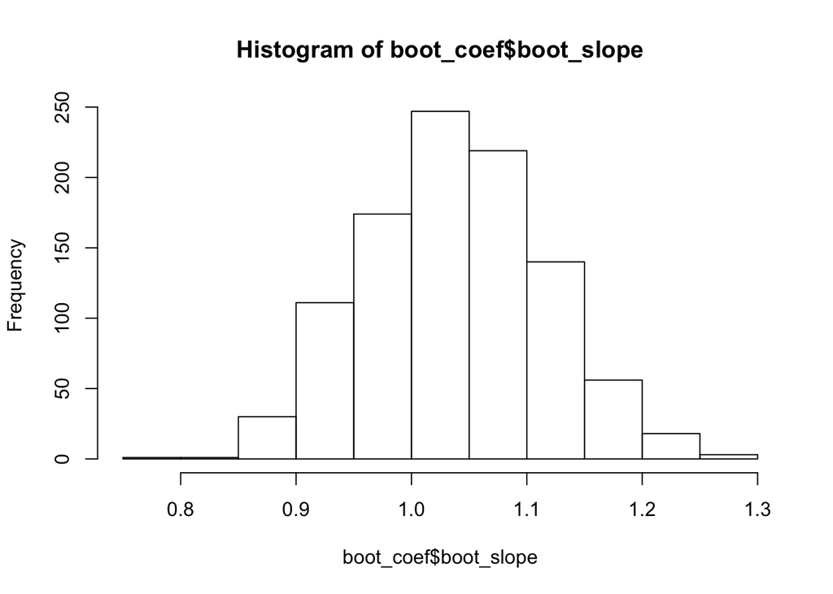

```r
hist(boot_coef$boot_slope)
```

#### standard error

```r
sd(boot_coef$boot_int)
```

```
## [1] 0.5995175
```

```r
sd(boot_coef$boot_slope)
```

```
## [1] 0.07864105
```

#### CI

For the intercept

```r
alpha <- 0.05
int_CI <- mean(boot_coef$boot_int) + c(-1, 1) * qt(1 - alpha / 2, df = n - 1) * sd(boot_coef$boot_int)
names(int_CI) <- c("lower","upper")
int_CI
```

```
##      lower      upper
## -10.643978  -8.272813
```

For the slope

```r
slope_CI <- mean(boot_coef$boot_slope) + c(-1, 1) * qt(1 - alpha / 2, df = n - 1) * sd(boot_coef$boot_slope)
names(slope_CI) <- c("lower","upper")
slope_CI
```

```
##    lower    upper
## 0.882228 1.193263
```

#### how do they compare to the model?

Model confidence intervals

```r
model <- lm(log(HomeRange_km2)~log(Body_mass_female_mean), data = d)
tidy(model)
```

```
## # A tibble: 2 x 5
##   term                       estimate std.error statistic  p.value
##   <chr>                         <dbl>     <dbl>     <dbl>    <dbl>
## 1 (Intercept)                   -9.44    0.673      -14.0 3.82e-28
## 2 log(Body_mass_female_mean)     1.04    0.0849      12.2 1.45e-23
```

```r
confint(model)
```

```
##                                  2.5 %    97.5 %
## (Intercept)                -10.7720889 -8.110374
## log(Body_mass_female_mean)   0.8685707  1.204292
```

The standard errors and CIs for both coeffecients from the bootstrap are fairly close close to that of the single linear model.

### Challenge 3

#### Write a function

It took so long to make to boot part of the the boot_lm. So I didn’t have time to combine my two functions…The first one gives the estimates, SE, and CI of the model alone and the second function is the boot function that only runs the bootstrapping and resturns results in a similar format but without the slope name….  
So perhaps there was no point in makeing the first function. I intended to put it in the boot_lm and combine the tables.

```r
lm_sum <-  function(d, model = "", conf.level = ""){
  mod <- lm(model, d)
  CI <- tidy(mod, conf.int = TRUE, conf.level = conf.level)
  CI %>% select(term, estimate, std.error, conf.low, conf.high)
}

boot_lm <- function(d, model = "", reps = "", conf.level = ""){

  # Setting up the boot strap
  n <- dim(d)[1]
  s <- list(length = reps)
  coef <- list(length = reps)

  for (i in 1:reps) {
    s[[i]] <- sample_n(d, size = n, replace = TRUE)
    m <- s[[i]]
    model <- lm(model, data = m)
    coef[[i]] <- model$coefficients
  }

  boot_Mat <- data.frame(matrix(unlist(coef), nrow=reps, byrow=T),stringsAsFactors=FALSE)
  names(boot_Mat) <- c("boot_int","boot_slope")
  #head(boot_Mat)

  # Get the se for the slope and intercept
  boot_slope_se <- sd(boot_Mat$boot_slope)
  boot_int_se <- sd(boot_Mat$boot_int)
  st.error <- rbind(boot_int_se, boot_slope_se)

  # CI of slope
  slope_CI <- mean(boot_Mat$boot_slope) + c(-1, 1) * qt(conf.level / 2, df = n - 1) * boot_slope_se
  names(slope_CI) <- c("conf.low","conf.high")
  head(slope_CI)

  # CI for the intercept
  int_CI <- mean(boot_Mat$boot_int) + c(-1, 1) * qt(conf.level / 2, df = n - 1) * boot_int_se
  names(int_CI) <- c("conf.low","conf.high")

  # bind them
  CIs <- rbind(int_CI,slope_CI)

  # Get the means of the coeffecients
  boot_slope_m <- mean(boot_Mat$boot_slope)
  boot_int_m <- mean(boot_Mat$boot_int)
  estimate <- rbind (boot_int_m, boot_slope_m) # bind them

  # Create data frame of mean coeffecients, se, and CI
  results <- cbind(estimate,st.error,CIs)
  resultd <- data.frame(results)
  colnames(results) <- c("estimate","std.error","conf.low","conf.high")
  rownames(results) <- c("intercept","slope")
  return(results)
}
```

#### Use the function

**Model 1:** log(HomeRange_km2) ~ log(Body_mass_female_mean)

```r
lm_sum(d, model = "log(HomeRange_km2) ~ log(Body_mass_female_mean)", conf.level = 0.95)
```

```
## # A tibble: 2 x 5
##   term                       estimate std.error conf.low conf.high
##   <chr>                         <dbl>     <dbl>    <dbl>     <dbl>
## 1 (Intercept)                   -9.44    0.673   -10.8       -8.11
## 2 log(Body_mass_female_mean)     1.04    0.0849    0.869      1.20
```

```r
boot_lm(d, model = "log(HomeRange_km2) ~ log(Body_mass_female_mean)", reps = 1000, conf.level = 0.95)
```

```
##            estimate  std.error  conf.low conf.high
## intercept -9.481797 0.57189144 -9.445893 -9.517701
## slope      1.040701 0.07307951  1.045289  1.036113
```

**Model 2:** log(DayLength_km) ~ log(Body_mass_female_mean)

```r
lm_sum(d, model = "log(DayLength_km) ~ log(Body_mass_female_mean)", conf.level = 0.95)
```

```
## # A tibble: 2 x 5
##   term                       estimate std.error conf.low conf.high
##   <chr>                         <dbl>     <dbl>    <dbl>     <dbl>
## 1 (Intercept)                 -0.143     0.465   -1.07       0.780
## 2 log(Body_mass_female_mean)   0.0389    0.0567  -0.0735     0.151
```

```r
boot_lm(d, model = "log(DayLength_km) ~ log(Body_mass_female_mean)", reps = 1000, conf.level = 0.95)
```

```
##              estimate  std.error    conf.low   conf.high
## intercept -0.14665881 0.45459703 -0.11811872 -0.17519889
## slope      0.03940657 0.05790942  0.04304219  0.03577096
```

**Model 3:** The last model, log(HomeRange_km2) ~ log(Body_mass_female_mean) + MeanGroupSize. *I have now realized the limits of my boot function….*

```r
log(HomeRange_km2) ~ log(Body_mass_female_mean) + MeanGroupSize
```

```
## log(HomeRange_km2) ~ log(Body_mass_female_mean) + MeanGroupSize
```

```r
lm_sum(d, model = "log(HomeRange_km2) ~ log(Body_mass_female_mean) + MeanGroupSize", conf.level = 0.95)
```

```
## # A tibble: 3 x 5
##   term                       estimate std.error conf.low conf.high
##   <chr>                         <dbl>     <dbl>    <dbl>     <dbl>
## 1 (Intercept)                 -8.66     0.698   -10.0      -7.27
## 2 log(Body_mass_female_mean)   0.850    0.0942    0.663     1.04
## 3 MeanGroupSize                0.0433   0.00789   0.0277    0.0590
```

```r
boot_lm(d, model = "log(HomeRange_km2) ~ log(Body_mass_female_mean) + MeanGroupSize", reps = 1000, conf.level = 0.95)
```

```
##             estimate std.error   conf.low  conf.high
## intercept -8.6838699 0.6166633 -8.6451551 -8.7225846
## slope      0.8526339 0.0818240  0.8577709  0.8474969
```